# Background

Janek

2026-03-28

```
## # A tibble: 1 × 12
##   mean_speechiness mean_acousticness mean_liveness sd_speechiness
##              <dbl>             <dbl>         <dbl>          <dbl>
## 1           0.0826             0.145         0.160         0.0634
## # ℹ 8 more variables: sd_acousticness <dbl>, sd_liveness <dbl>,
## #   median_speechiness <dbl>, median_acousticness <dbl>, median_liveness <dbl>,
## #   mad_speechiness <dbl>, mad_acousticness <dbl>, mad_liveness <dbl>
```

After having loaded the playlist, I will compute the transition distance across all features. This will allow me to check for spikes along the playlist length to see which moments or tracks have the least smooth transitions so that I can focus on those.

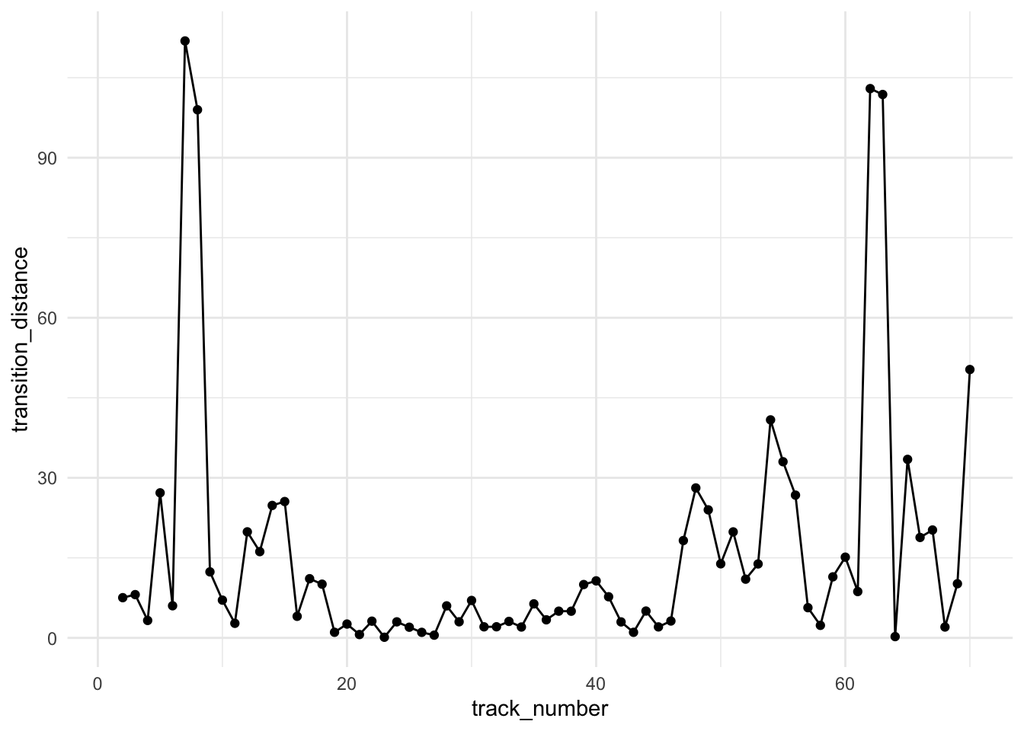

Note that the distances of subsequent points on the graph does not correspong to a bigger spike, but for each track the transition distance from the previous one is shown. This means that everywhere there is a spike, there is a large transition distance.  
Also as the first song has none before it, it is omitted from the graph, we start with the second track

```
## # A tibble: 5 × 4
##   previous_track                   `Track Name` track_number transition_distance
##   <chr>                            <chr>               <int>               <dbl>
## 1 Find Your State of Mind          I'll Be wit…            7               112.
## 2 Sex Jam                          Lose Yourse…           62               103.
## 3 Lose Yourself to Dance (Drumles… Daybreak               63               102.
## 4 I'll Be with You                 Hung Up On …            8                99.0
## 5 Goldrush                         Words 2B He…           70                50.3
```

To be sure that my ordering of the track influenced the Spotify track level features of the playlist at all, I will compare the mean multivariate distance of both my playlist and the same songs from it ordered in a random way.

```
## [1] 16.10753
```

```
## [1] 18.71683
```

This shows that my ordering did indeed influence the Spotify track level features positively, as expected. The mean multivariate distance between tracks is lower in my playlist than in a randomly ordered one.

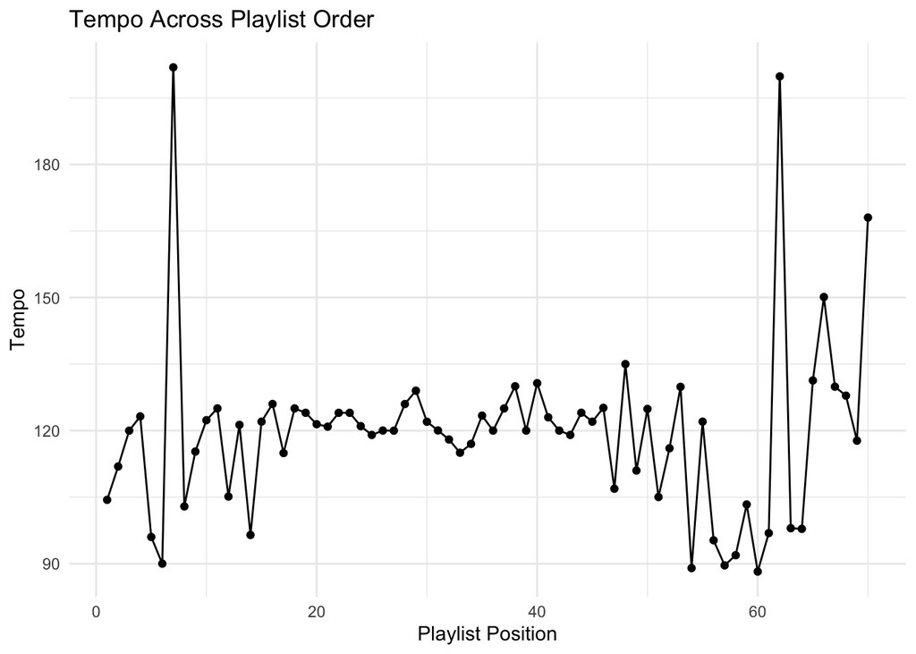

```
## # A tibble: 2 × 2
##   track_number Tempo
##          <int> <dbl>
## 1            7 101.
## 2           62  99.9
```

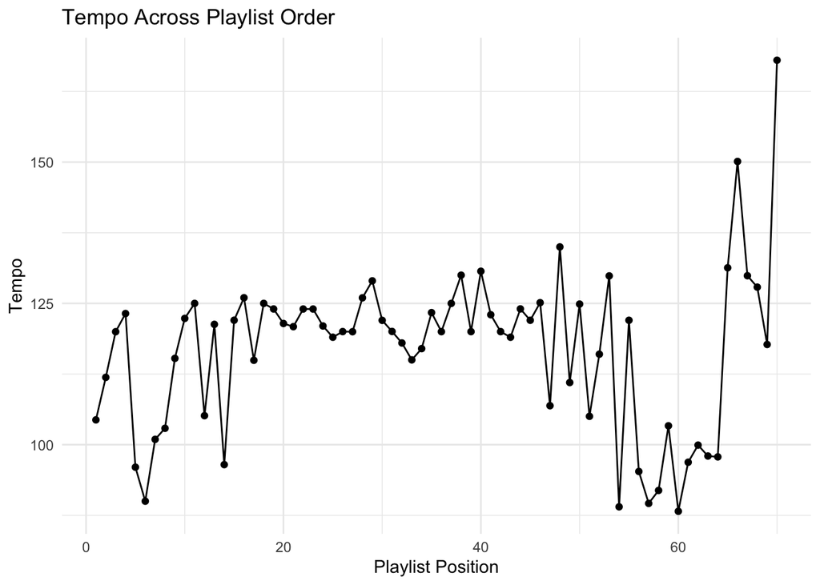

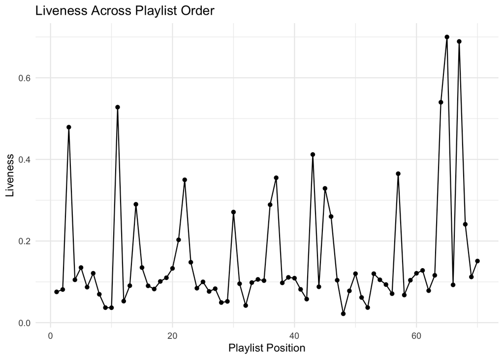

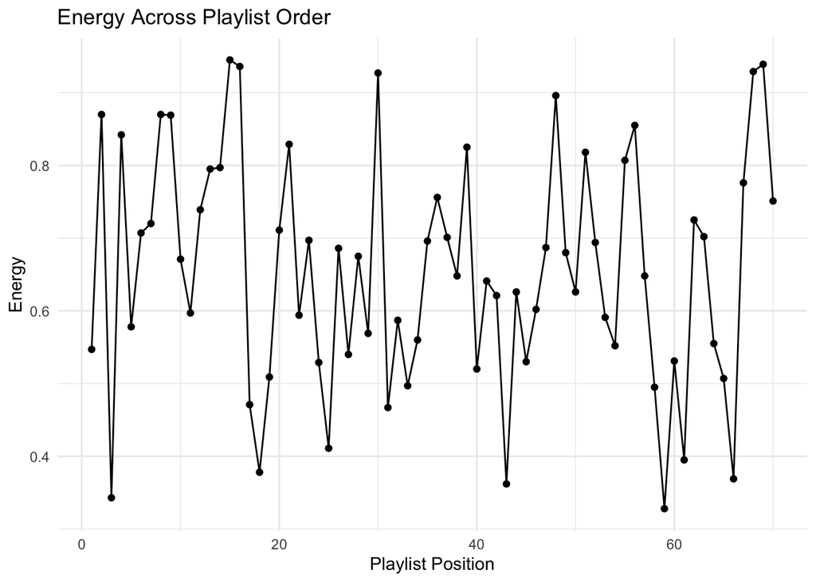

```
## # A tibble: 5 × 4
##   previous_track                  `Track Name`           track_number tempo_diff
##   <chr>                           <chr>                         <int>      <dbl>
## 1 Goldrush                        Words 2B Heard Meets …           70       50.3
## 2 Song of Life - Remastered       Freefall (feat. Malco…           54       40.9
## 3 NaaNaaNaa - Live                Sunny                            65       33.5
## 4 Freefall (feat. Malcolm Duncan) Bonita Applebum - Sir…           55       33.0
## 5 Veridis Quo                     Two Months Off                   48       28.1
```

```
## # A tibble: 5 × 4
##   previous_track         `Track Name`           track_number liveness_diff
##   <chr>                  <chr>                         <int>         <dbl>
## 1 Sunny                  All But Blind                    66         0.607
## 2 All But Blind          Lingus                           67         0.596
## 3 It's Serious           There's A Better Place           11         0.491
## 4 There's A Better Place Take Me I'm Yours                12         0.475
## 5 Lingus                 Spybreak!                        68         0.448
```

```
## # A tibble: 5 × 4
##   previous_track                           `Track Name` track_number energy_diff
##   <chr>                                    <chr>               <int>       <dbl>
## 1 Cosmic Interlude                         I'm Doing F…            3       0.527
## 2 I'm Doing Fine (feat. Amp Dog Knight)    Could Heave…            4       0.499
## 3 If Only I Could (feat. Steve Lucas) - L… King Bromel…           17       0.465
## 4 Szikra                                   Waiting                31       0.46
## 5 All But Blind                            Lingus                 67       0.407
```

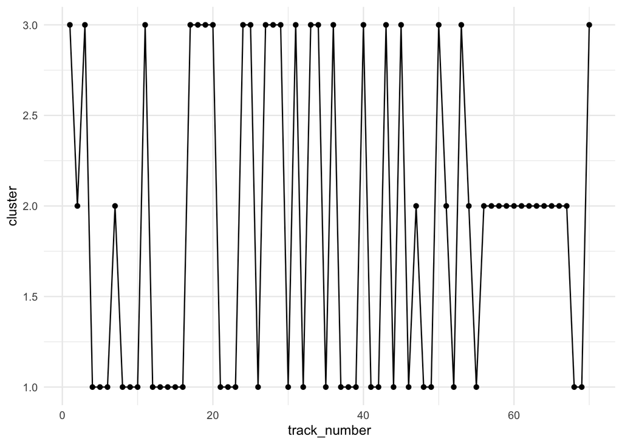

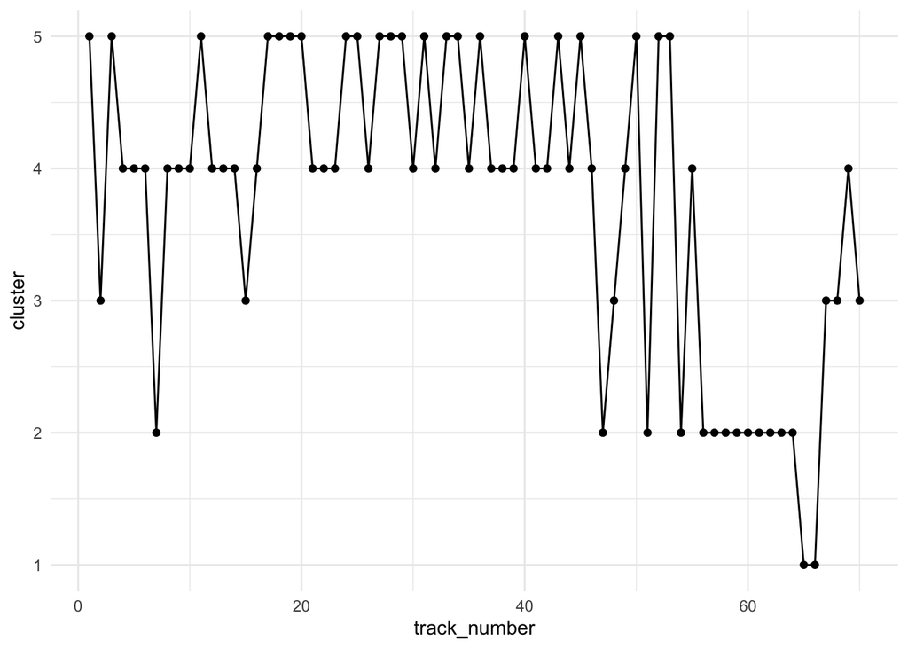

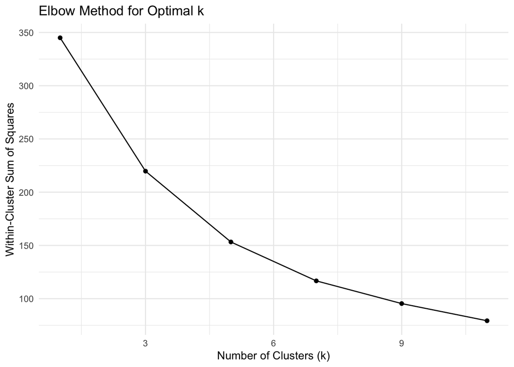

# Welcome

### About the Repository

This repository was created for the course **Computational Musicology** at the University of Amsterdam.  
It contains an analysis of a selected corpus of music from my playlist *“I Don’t Want This Groove to Ever End”*.

### The Playlist

The playlist *“I Don’t Want This Groove to Ever End”*, named after its first track, is a collection of what I find groovy songs: **tracks that are heavily based on a looped or recurring musical phrase or rhythmic pattern**. Only songs of around 6 minutes or longer get added to this playlist, to allow the listener to immerse themselves in each one.

The tracks are mostly unique and vary greatly, and hearing a contrasting groove immediately after another can disrupt the listening experience. To prevent this, I have put a lot of thought into arranging their order.

here you can view the playlist and listen to some of its tracks:

[interactive chart not shown]

### The Analysis

The goal of the conducted analysis will be to show how well some musical features can be used to determine the order of the playlist, based on the similarity of the tracks. The following musical featuers will be used: - like Spotify track-level features, - chroma, timbre, and temporal features, - and volume or loudness